# Google Colab Tutorial

- By Prof. Dr. Mohammad Mahdavi
- [GISMA University of Applied Sciences](https://www.gisma.com/)

[Jupyter Notebook](https://jupyter.org/) (formerly IPython Notebook) is a web-based interactive computational environment for creating notebook documents. In these notebooks, you can write both textual reports and executable codes. [Google Colab](https://colab.research.google.com/) allows you to create Jupyter Notebooks to write and execute Python in your browser using Google's servers. This page is an example of a Jupyter Notebook (or more specifically a Colab Notebook). In this short tutorial, we will review how to work with these Jupyter/Colab Notebooks.

## Creating/Uploading Jupyter Notebooks

You can create or upload a new Jupyter Notebook via the `File` menu. You can also load a notebook directly from a GitHub repository.

[figure not shown]

## Adding Text Cells

You can add text cells by clicking on the above `+Text` button. You can write **decorated** reports in these text cells using the [markdown language.](https://www.markdownguide.org/basic-syntax/)

## Adding Code Cells

You can add Python code cells by clicking on the above `+Code` button. Run your codes using the play button.

```python
print("Hello World!")
```

```
Hello World!
```

## Adding Images

When you need to add any image to your Jupyter Notebook, please always embed your image via the `insert image` button, which is visible on the top of the code cells while you are editing them. Alternatively, you can use the below sample code to insert images. Note that `image_address` can be a URL or the path of your image file on your file system.

If you use other approaches to add images, your image might not be shown in the final exported version of the Jupyter Notebook, when you submit it without attaching the image file.

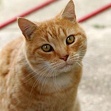

```python
import IPython.display

image_address = "https://upload.wikimedia.org/wikipedia/commons/thumb/3/3a/Cat03.jpg/220px-Cat03.jpg"    # or for example "image.jpg"
IPython.display.Image(image_address)
```

## Uploading a Dataset

You can upload your own data into Jupyter Notebooks from your local computer. The below code cell allows you to upload a local file to Colab. For example, we upload the `iris.csv` dataset.

```python
import google.colab

uploaded = google.colab.files.upload()
```

```
Saving iris.csv to iris.csv
```

After uploading the `iris.csv` file, we can now load this dataset and use it in our Jupyter Notebook using the below code cell.

```python
import pandas as pd

df = pd.read_csv("iris.csv")
df.head()
```

|  | id | sepal length (cm) | sepal width (cm) | petal length (cm) | petal width (cm) | target |
| --- | --- | --- | --- | --- | --- | --- |
| 0 | 0 | 5.1 | 3.5 | 1.4 | 0.2 | setosa |
| 1 | 1 | 4.9 | 3.0 | 1.4 | 0.2 | setosa |
| 2 | 2 | 4.7 | 3.2 | 1.3 | 0.2 | setosa |
| 3 | 3 | 4.6 | 3.1 | 1.5 | 0.2 | setosa |
| 4 | 4 | 5.0 | 3.6 | 1.4 | 0.2 | setosa |

## Saving the Jupyter Notebook

Once you save your Jupyter Notebook via `Files > Save`, the current notebook will be saved in the `Colab Notebooks` folder on your Google Drive.

## Exporting the Jupyter Notebook

For submitting your assignments, you need to convert your Jupyter Notebook to an `HTML` file. If your Jupyter Notebook is already loaded on Google Colab via the left pane, you can simply convert your notebook to HTML via the below command. Note that you should replace `google_colab_tutorial.ipynb` with the path/name of your loaded Jupyter Notebook. Then, you can press the refresh button on the left pane and see/download the HTML version of your notebook. Watch this [video](https://www.youtube.com/watch?v=3vfRhVL5DyM) for more information.

```python
!jupyter nbconvert --to html google_colab_tutorial.ipynb
```

```
[NbConvertApp] Converting notebook google_colab_tutorial.ipynb to html
[NbConvertApp] Writing 306142 bytes to google_colab_tutorial.html
```

## More Resources

- [Welcome to Colab](https://colab.research.google.com/)
- [Introduction to Colab](https://www.youtube.com/watch?v=inN8seMm7UI)
- Overview of Colaboratory
- Guide to Markdown
- Importing Libraries and Installing Dependencies
- [Saving and Loading Notebooks in GitHub](https://colab.research.google.com/github/googlecolab/colabtools/blob/main/notebooks/colab-github-demo.ipynb)
- Interactive Forms
- Interactive Widgets
- Loading Data: Drive, Sheets, and Google Cloud Storage